# HW1_harinris

Harin Rishabh

2023-09-20

# Lab 2.3

## 2.3.1 - Basic Commands

Create 2 vectors:

```r
x <- c(1, 2, 3, 4)
y = c(5, 6, 7 ,8)

x
```

```
## [1] 1 2 3 4
```

```r
length(y)
```

```
## [1] 4
```

Add 2 sets of numbers

```r
x + y
```

```
## [1]  6  8 10 12
```

List and delete objects

```r
ls()
```

```
## [1] "x" "y"
```

```r
rm(x)
ls()
```

```
## [1] "y"
```

```r
a = 10
b = 20
ls()
```

```
## [1] "a" "b" "y"
```

```r
rm(list = ls())
ls()
```

```
## character(0)
```

```r
seq(-pi, pi, length = 7)
```

```
## [1] -3.141593 -2.094395 -1.047198  0.000000  1.047198  2.094395  3.141593
```

Matrix - Creating a matrix and performing basic calculations

```r
x = matrix(data = c(1, 2, 3, 4), nrow = 2, ncol = 2, byrow = TRUE)
x
```

```
##      [,1] [,2]
## [1,]    1    2
## [2,]    3    4
```

```r
sqrt(x)
```

```
##          [,1]     [,2]
## [1,] 1.000000 1.414214
## [2,] 1.732051 2.000000
```

```r
x^2
```

```
##      [,1] [,2]
## [1,]    1    4
## [2,]    9   16
```

Generating 2 vectors of random normal variables and computing correlation between them

```r
a = rnorm(50)
b = a + rnorm(50, mean = 50, sd = 0.1)
cor(a, b)
```

```
## [1] 0.9946231
```

Using set.seed to setup a pseudo-random number generator

```r
set.seed(3)
x = rnorm(100)
mean(x)
```

```
## [1] 0.01103557
```

```r
var(x)
```

```
## [1] 0.7328675
```

```r
sqrt(var(x))
```

```
## [1] 0.8560768
```

```r
sd(x)
```

```
## [1] 0.8560768
```

## 2.3.2 - Graphics

Plotting graphs with labels and saving as PDF

```r
pdf("Figure.pdf")
x = rnorm(100)
y = rnorm(100)
plot(x, y, xlab = "X-axis", ylab = "Y-axis", main = "This a graph of X vs Y")
dev.off()
```

Using the contour() and persp() function to plot 3-D graphs

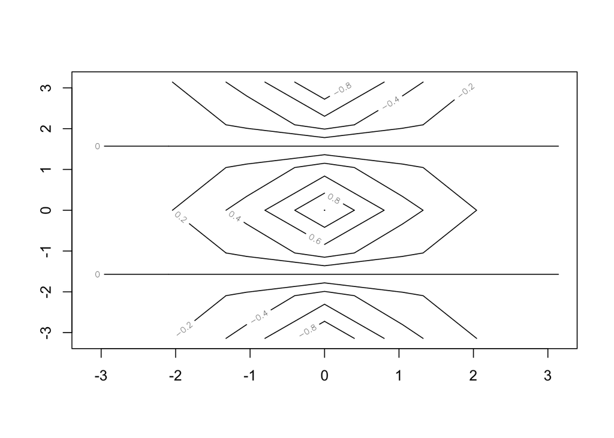

```r
x = seq(-pi, pi, length = 7)
y = x
f = outer(x, y, function(x , y) cos (y) / (1 + x^2))
contour(x, y, f)
```

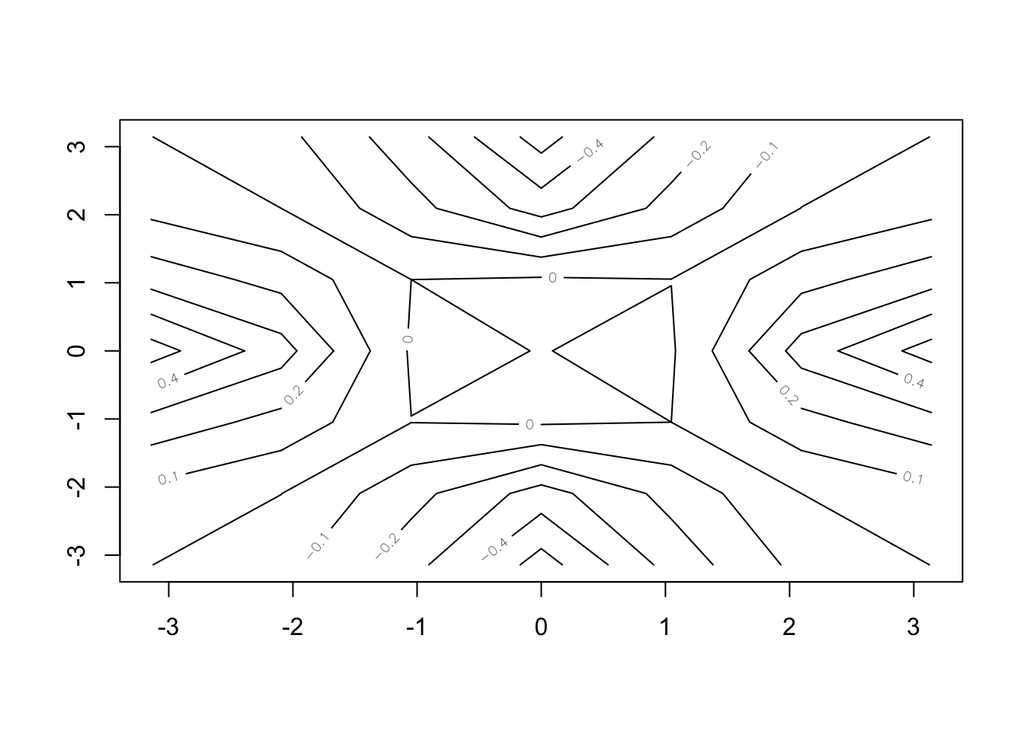

```r
fa = (f - t (f)) / 2
contour(x, y, fa, nlevels = 15)
```

Using image() to plot 3-D graphs

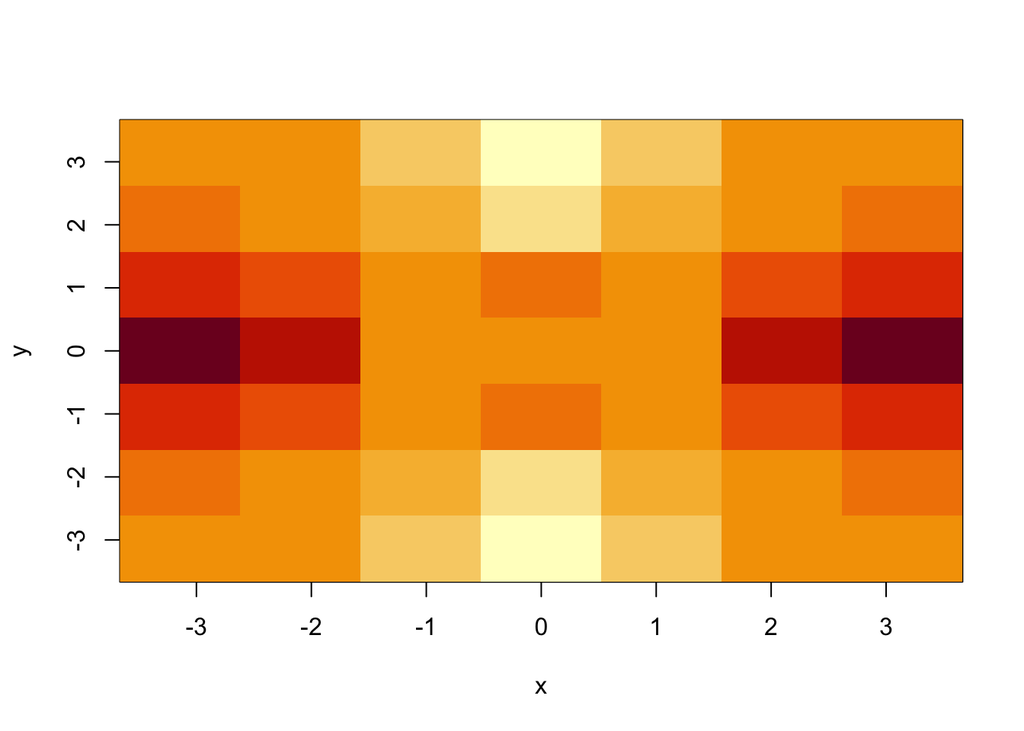

```r
image(x, y, fa)
```

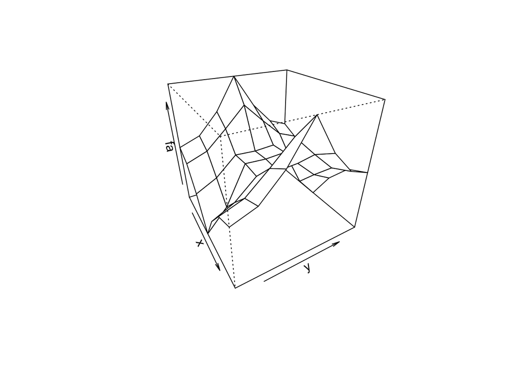

```r
persp(x, y, fa, theta = 60, phi = 30)
```

## 2.3.3 - Indexing Data

Exploring different ways to examine a portion of the dataset or refer to particular elements by index

```r
A = matrix(1:16, 4, 4)
A
```

```
##      [,1] [,2] [,3] [,4]
## [1,]    1    5    9   13
## [2,]    2    6   10   14
## [3,]    3    7   11   15
## [4,]    4    8   12   16
```

```r
A[3, 3]
```

```
## [1] 11
```

```r
A [c(1, 3), c(2, 4)]
```

```
##      [,1] [,2]
## [1,]    5   13
## [2,]    7   15
```

```r
A[1:3, 2:4]
```

```
##      [,1] [,2] [,3]
## [1,]    5    9   13
## [2,]    6   10   14
## [3,]    7   11   15
```

```r
A[1:2,]
```

```
##      [,1] [,2] [,3] [,4]
## [1,]    1    5    9   13
## [2,]    2    6   10   14
```

```r
A[, 1:2]
```

```
##      [,1] [,2]
## [1,]    1    5
## [2,]    2    6
## [3,]    3    7
## [4,]    4    8
```

```r
A[-c(1, 3), ]
```

```
##      [,1] [,2] [,3] [,4]
## [1,]    2    6   10   14
## [2,]    4    8   12   16
```

```r
dim(A)
```

```
## [1] 4 4
```

## 2.3.4 - Loading Data

```r
library('ISLR')
head(Auto)
```

```
##   mpg cylinders displacement horsepower weight acceleration year origin
## 1  18         8          307        130   3504         12.0   70      1
## 2  15         8          350        165   3693         11.5   70      1
## 3  18         8          318        150   3436         11.0   70      1
## 4  16         8          304        150   3433         12.0   70      1
## 5  17         8          302        140   3449         10.5   70      1
## 6  15         8          429        198   4341         10.0   70      1
##                        name
## 1 chevrolet chevelle malibu
## 2         buick skylark 320
## 3        plymouth satellite
## 4             amc rebel sst
## 5               ford torino
## 6          ford galaxie 500
```

```r
dim(Auto)
```

```
## [1] 392   9
```

```r
Auto = na.omit(Auto)
dim(Auto)
```

```
## [1] 392   9
```

```r
names(Auto)
```

```
## [1] "mpg"          "cylinders"    "displacement" "horsepower"   "weight"
## [6] "acceleration" "year"         "origin"       "name"
```

## 2.3.5 - Additional Graphical and Numerical Summaries

Plotting graphs using values in Auto data set. Data set can be refered to by $ sign.

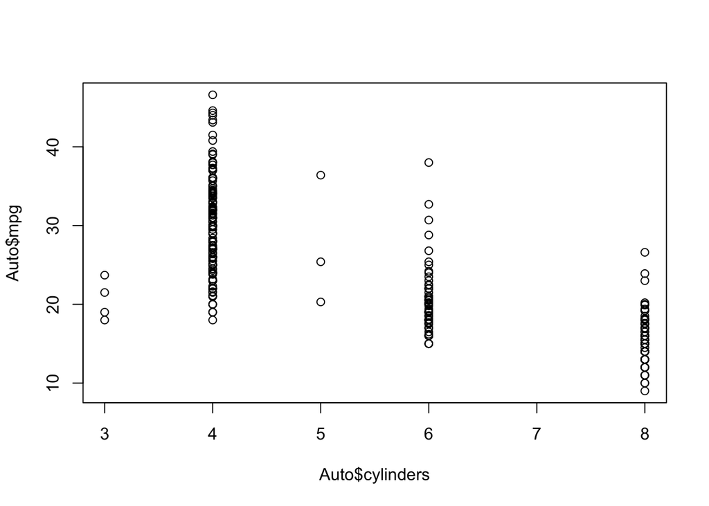

```r
plot(Auto$cylinders, Auto$mpg)
```

Or by using attach() to make the variables in this data frame available by name.

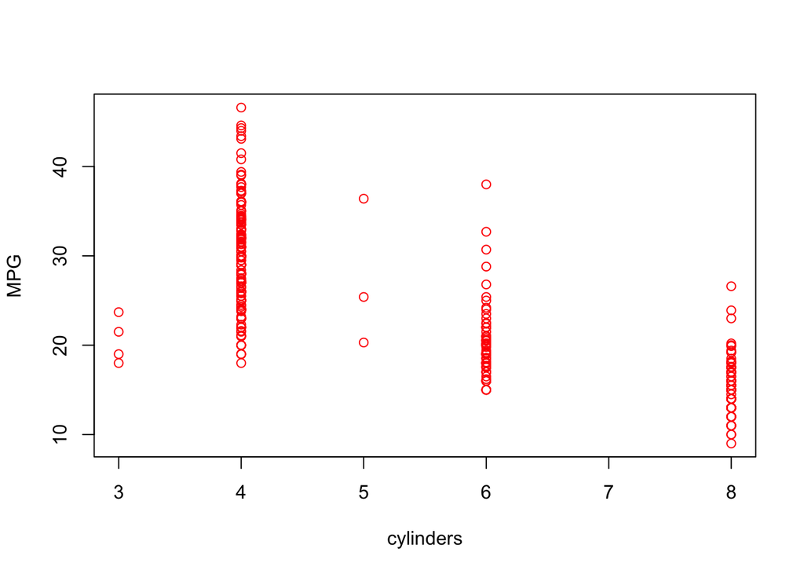

```r
attach(Auto)
plot(cylinders, mpg, col = "red", xlab = "cylinders", ylab = "MPG")
```

hist() is used to plot Histograms.

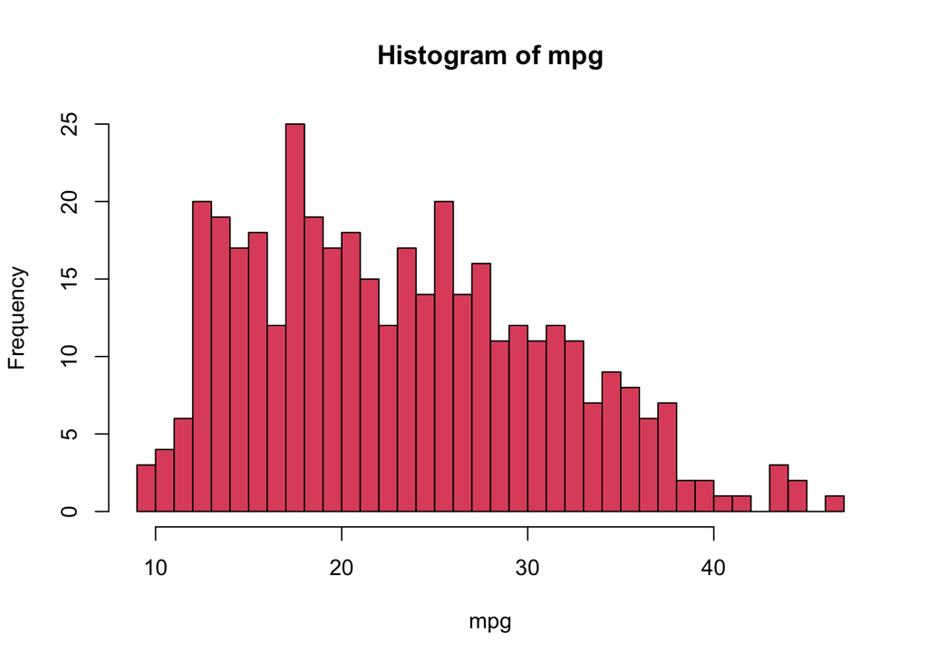

```r
hist(mpg, col = 2, breaks = 50)
```

pairs() creates a scatterplot for every pair of variables. We can also produce scatterplots for just a subset of the variables.

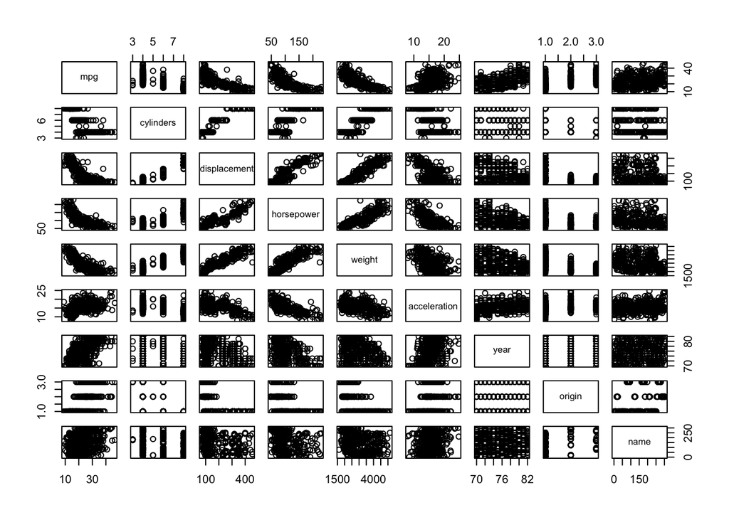

```r
pairs(Auto)
```

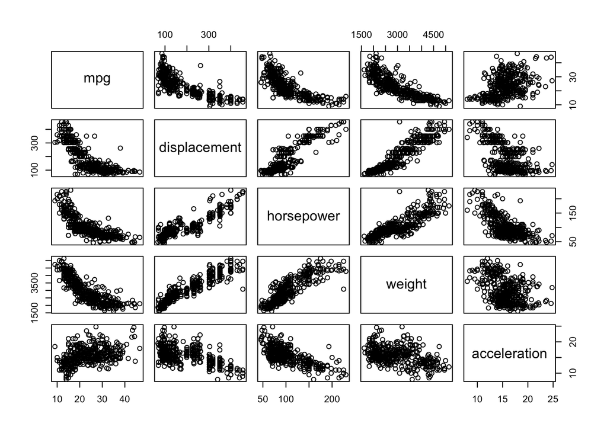

```r
pairs(~ mpg + displacement + horsepower + weight + acceleration, data = Auto)
```

We can use summary() to view a numerical summary of each variable in a particular data set.

```r
summary(Auto)
```

```
##       mpg          cylinders      displacement     horsepower        weight
##  Min.   : 9.00   Min.   :3.000   Min.   : 68.0   Min.   : 46.0   Min.   :1613
##  1st Qu.:17.00   1st Qu.:4.000   1st Qu.:105.0   1st Qu.: 75.0   1st Qu.:2225
##  Median :22.75   Median :4.000   Median :151.0   Median : 93.5   Median :2804
##  Mean   :23.45   Mean   :5.472   Mean   :194.4   Mean   :104.5   Mean   :2978
##  3rd Qu.:29.00   3rd Qu.:8.000   3rd Qu.:275.8   3rd Qu.:126.0   3rd Qu.:3615
##  Max.   :46.60   Max.   :8.000   Max.   :455.0   Max.   :230.0   Max.   :5140
##
##   acceleration        year           origin                      name
##  Min.   : 8.00   Min.   :70.00   Min.   :1.000   amc matador       :  5
##  1st Qu.:13.78   1st Qu.:73.00   1st Qu.:1.000   ford pinto        :  5
##  Median :15.50   Median :76.00   Median :1.000   toyota corolla    :  5
##  Mean   :15.54   Mean   :75.98   Mean   :1.577   amc gremlin       :  4
##  3rd Qu.:17.02   3rd Qu.:79.00   3rd Qu.:2.000   amc hornet        :  4
##  Max.   :24.80   Max.   :82.00   Max.   :3.000   chevrolet chevette:  4
##                                                  (Other)           :365
```

```r
summary(mpg)
```

```
##    Min. 1st Qu.  Median    Mean 3rd Qu.    Max.
##    9.00   17.00   22.75   23.45   29.00   46.60
```

# Exercise 2.4

**9. This exercise involves the Auto data set studied in the lab. Make sure that the missing values have been removed from the data.**  
**(a) Which of the predictors are quantitative, and which are qualitative?**  
Answer - MPG, Displacement, Horsepower, Weight and Acceleration are Quantitative predictors. Cylinders, name, year and origin are Qualitative predictors.

**(b) What is the range of each quantitative predictor? You can answer this using the range() function.**  
Answer -

```r
Auto = na.omit(Auto)
range(mpg)   # Range of MPG
```

```
## [1]  9.0 46.6
```

```r
range(displacement)   # Range of Displacement
```

```
## [1]  68 455
```

```r
range(horsepower)   # Range of Horsepower
```

```
## [1]  46 230
```

```r
range(weight)   # Range of Weight
```

```
## [1] 1613 5140
```

```r
range(acceleration)   # Range of Acceleration
```

```
## [1]  8.0 24.8
```

**c) What is the mean and standard deviation of each quantitative predictor?**  
Answer -

```r
Auto = na.omit(Auto)
mean(mpg)   # Mean of MPG
```

```
## [1] 23.44592
```

```r
sd(mpg)   # Standard Deviation of MPG
```

```
## [1] 7.805007
```

```r
mean(displacement)   # Mean of Displacement
```

```
## [1] 194.412
```

```r
sd(displacement)   # Standard Deviation of Displacement
```

```
## [1] 104.644
```

```r
mean(horsepower)   # Mean of horsepower
```

```
## [1] 104.4694
```

```r
sd(horsepower)   # Standard Deviation of Horsepower
```

```
## [1] 38.49116
```

```r
mean(weight)   # Mean of Weight
```

```
## [1] 2977.584
```

```r
sd(weight)   # Standard Deviation of Weight
```

```
## [1] 849.4026
```

```r
mean(acceleration)   # Mean of Acceleration
```

```
## [1] 15.54133
```

```r
sd(acceleration)   # Standard Deviation of Acceleration
```

```
## [1] 2.758864
```

```r
Auto2 = Auto[-(10:84),]
attach(Auto2)
range(mpg)   # Range of MPG
```

```
## [1] 11.0 46.6
```

```r
range(displacement)   # Range of Displacement
```

```
## [1]  68 455
```

```r
range(horsepower)   # Range of Horsepower
```

```
## [1]  46 230
```

```r
range(weight)   # Range of Weight
```

```
## [1] 1649 4997
```

```r
range(acceleration)   # Range of Acceleration
```

```
## [1]  8.5 24.8
```

```r
mean(mpg)   # Mean of MPG
```

```
## [1] 24.36845
```

```r
sd(mpg)   # Standard Deviation of MPG
```

```
## [1] 7.880898
```

```r
mean(displacement)   # Mean of Displacement
```

```
## [1] 187.7539
```

```r
sd(displacement)   # Standard Deviation of Displacement
```

```
## [1] 99.93949
```

```r
mean(horsepower)   # Mean of horsepower
```

```
## [1] 100.9558
```

```r
sd(horsepower)   # Standard Deviation of Horsepower
```

```
## [1] 35.89557
```

```r
mean(weight)   # Mean of Weight
```

```
## [1] 2939.644
```

```r
sd(weight)   # Standard Deviation of Weight
```

```
## [1] 812.6496
```

```r
mean(acceleration)   # Mean of Acceleration
```

```
## [1] 15.7183
```

```r
sd(acceleration)   # Standard Deviation of Acceleration
```

```
## [1] 2.693813
```

**(e) Using the full data set, investigate the predictors graphically, using scatter plots or other tools of your choice. Create some plots highlighting the relationships among the predictors. Comment on your findings.**  
Answer -

```r
attach(Auto)
```

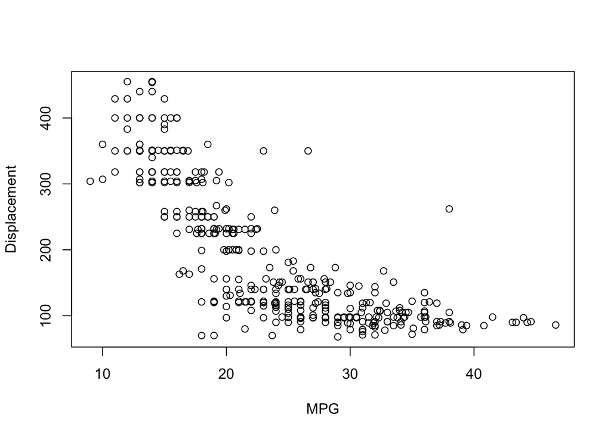

```r
plot(mpg, displacement, xlab = "MPG", ylab = "Displacement")
```

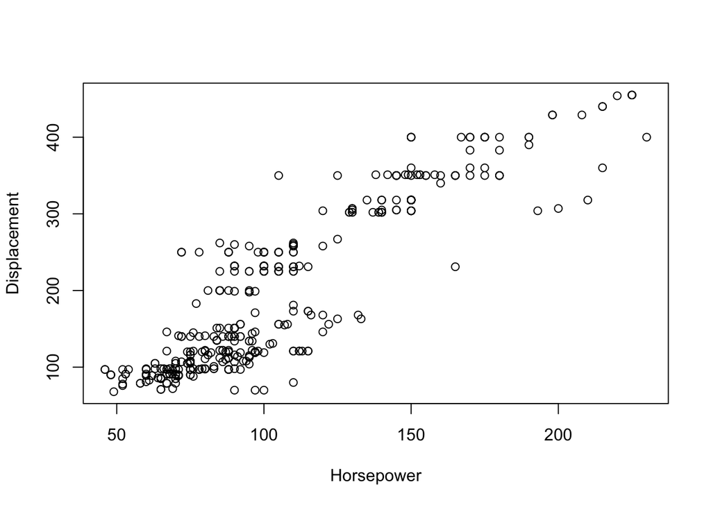

```r
# This graphs shows us that more the displacement of the engine, lower the Miles per gallon(mileage)

plot(horsepower, displacement, xlab = "Horsepower", ylab = "Displacement")
```